# 605-HW11-Regression

### Plot histograms of Residuals

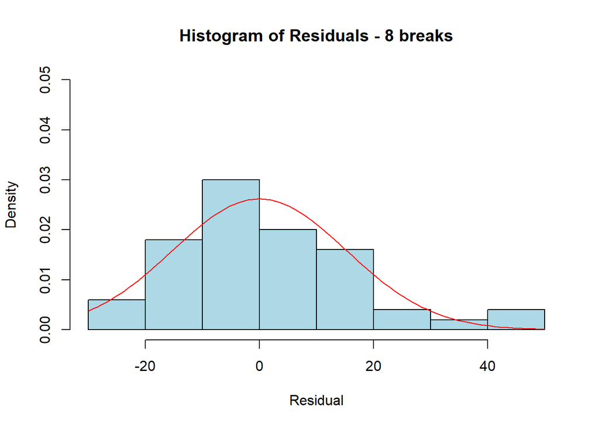

```r
Residual = resid(LinearModel)
hist(Residual, main = "Histogram of Residuals - 8 breaks", ylab = "Density",
     ylim = c(0, 0.05),prob = TRUE,breaks=8, col="lightblue")
curve(dnorm(x, mean = mean(Residual), sd = sd(Residual)), col="red", add=TRUE)
```

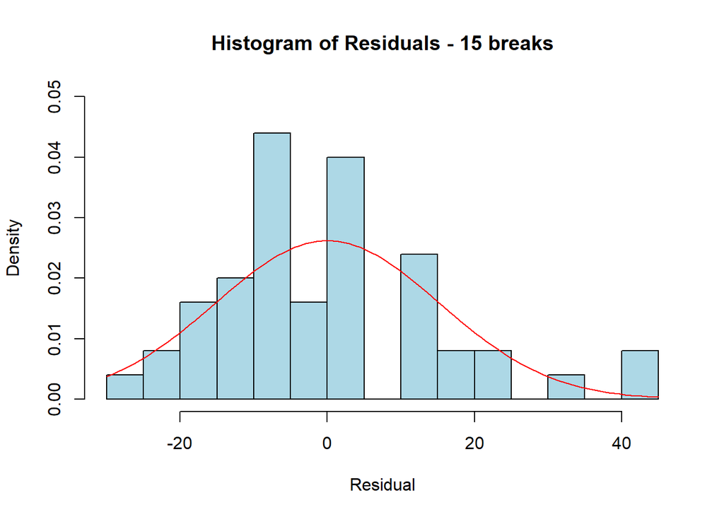

```r
hist(Residual, main = "Histogram of Residuals - 15 breaks", ylab = "Density",
     ylim = c(0, 0.05),prob = TRUE,breaks=15, col="lightblue")
curve(dnorm(x, mean = mean(Residual), sd = sd(Residual)), col="red", add=TRUE)
```

While the mean of the residuals is, by definition, zero, the **median** is **-2.27** .  
The number of observations for which the residual is negative is **27**,  
while the number of cases for which the residual is positive is **23** .  
These figures are consistent with the graphs shown above.  
Because the sample size is so small, it is difficult to determine from the above whether or not Normality is achieved.

### Shapiro-Wilks test

$H_0$ : The residuals *are* normal $H_A$ : The residuals are *not* normal

```r
shapiro.test(Residual)
```

```
##
##  Shapiro-Wilk normality test
##
## data:  Residual
## W = 0.9450906, p-value = 0.0215246
```

Because the p-value (0.0215) is low, the null hypothesis is **rejected** at 95% confidence. This indicates that the residuals are **not** sufficiently close to the normal distribution to meet the conditions of linear regression.

## More Plots

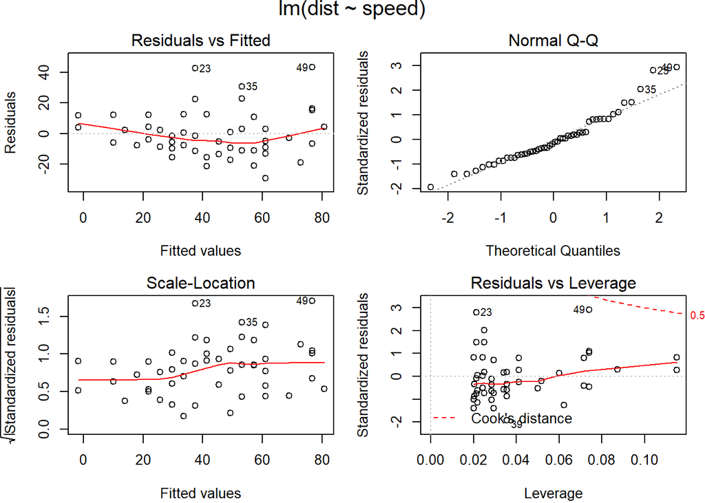

```r
opar1 <- par(mfrow = c(2, 2),
            oma = c(0, 0, 1.1, 0),
            mar = c(4.1, 4.1, 2.1, 1.1))
plot(LinearModel)
```

```r
par(opar1)
```

## Conclusion

Although the conditions for linear regression are questionable due to a few outliers resulting in failure of the normality test on the residuals, the model is significant and the results seem adequate in explaining that about ${\frac{2}{3}}$ of the variance in stopping distance is attributable to speed, while the other ${\frac{1}{3}}$ of the variance remains unexplained by this model and thus must be attributable to other factors which have not been modeled.